# Binary effects of sediment on coral fertilization

Lillian J. Tuttle

9/24/2020

#### Here I will explore how SUSPENDED sediment affects the FERTILIZATION SUCCESS of tropical, scleractinean corals. The database to be used is comprised of data extracted from studies deemed relevant during the systematic literature review process.

# The Dataset

```
##     n
## 1 110
```

```
##      Ref  n
## 1  SS14c 43
## 2  SS21a 23
## 3  SS11a 12
## 4  SS19a  6
## 5  SS21b  6
## 6  SS13a  5
## 7  SS14a  5
## 8  SS19b  4
## 9   SS07  3
## 10 SS14b  3
```

```
##                  Ref_name  n
## 1    Humphrey et al. 2008 51
## 2     Ricardo et al. 2018 29
## 3            Gilmour 1999 12
## 4     Ricardo et al. 2015 10
## 5    Humanes et al. 2017b  5
## 6 Erftemeijer et al. 2012  3
```

```
##     Ocean   n
## 1 Pacific 107
## 2  Indian   3
```

```
##                   Gsp  n
## 1 Acropora_digitifera 12
## 2  Acropora_millepora 61
## 3     Acropora_tenuis 34
## 4     Pectina_lactusa  3
```

```
##   Updated_Genus   n
## 1      Acropora 107
## 2       Pectina   3
```

# Exploratory plots

First let’s explore all data from all species for which there is data about ‘fertilization’ as a result of exposure to suspended sediment.

##### DEFINITIONS:

- ‘**Fertilization success**’ is defined as successful fertilization of coral eggs (existence of gamete) when exposed to sediment, as compared to surfaces without sediment (or “control” conditions).

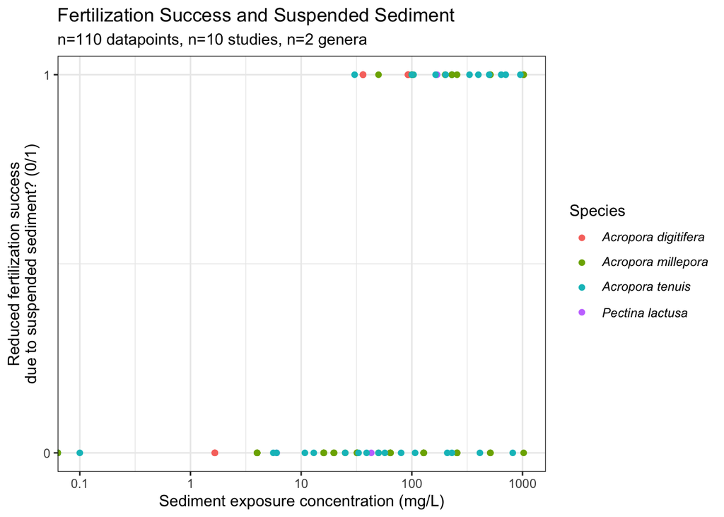

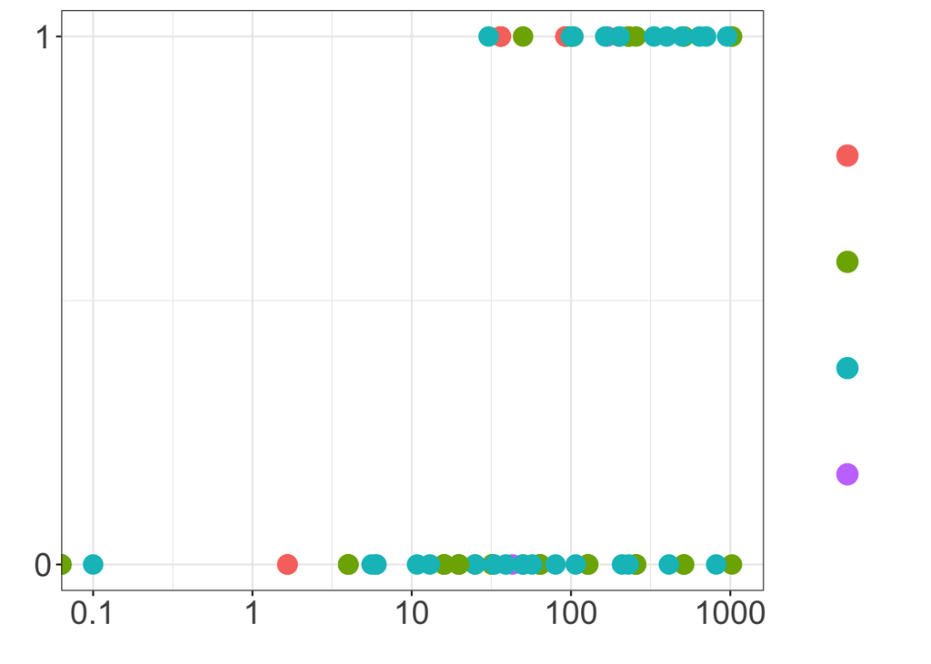

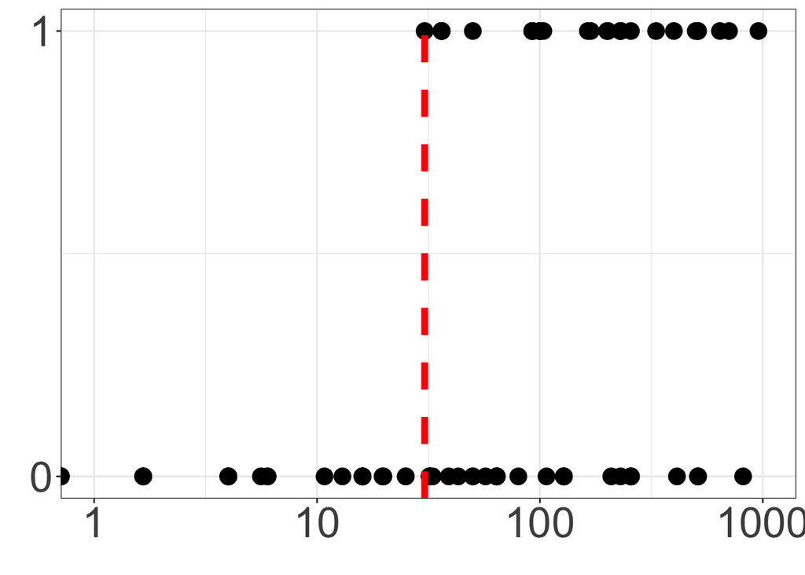

# Threshold Analyses with Binary Data

Now let’s calculate the thresholds, based on the binary data explored above.

##### DEFINITIONS:

- ‘**LOAEL**’, or the ‘lowest observed adverse effect level’ is defined as the lowest dose at which there was an observed adverse effect.
- ‘**NOAEL**’, or the ‘no observed adverse effect level’ is defined as the highest dose at which there was NOT an observed adverse effect.
- ‘**Adverse effect**’ is defined here as any response of a coral individual, colony, or experimental treatment group that *may* negatively affect the coral’s fitness and/or survival. These adverse effects may include sublethal physiological changes (e.g., significantly reduced growth or photosynthetic rates when compared to coral in ambient/control conditions), bleaching/tissue loss, and mortality. This definition of adverse effect is independent of its magnitude, so while the affect may have potentially reduced fitness, its magnitude may be sufficiently small that the fitness effect is not measureable.

```
##   LOAEL
## 1  30.4
```

```
##   NOAEL
## 1    25
```

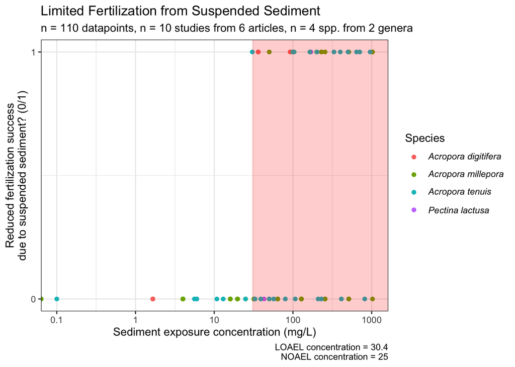

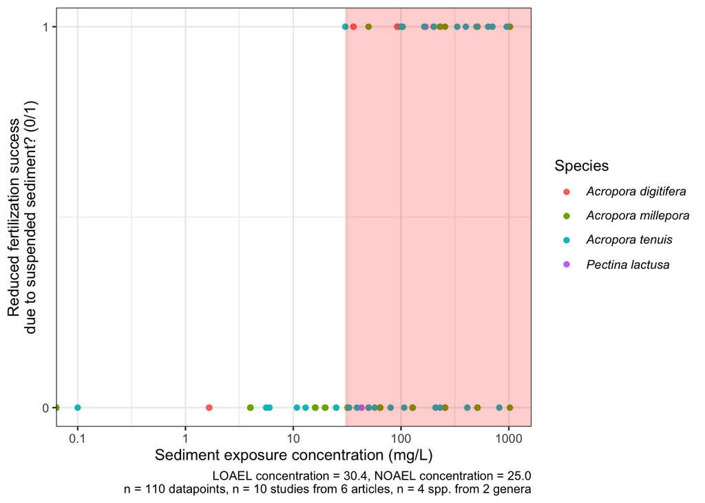

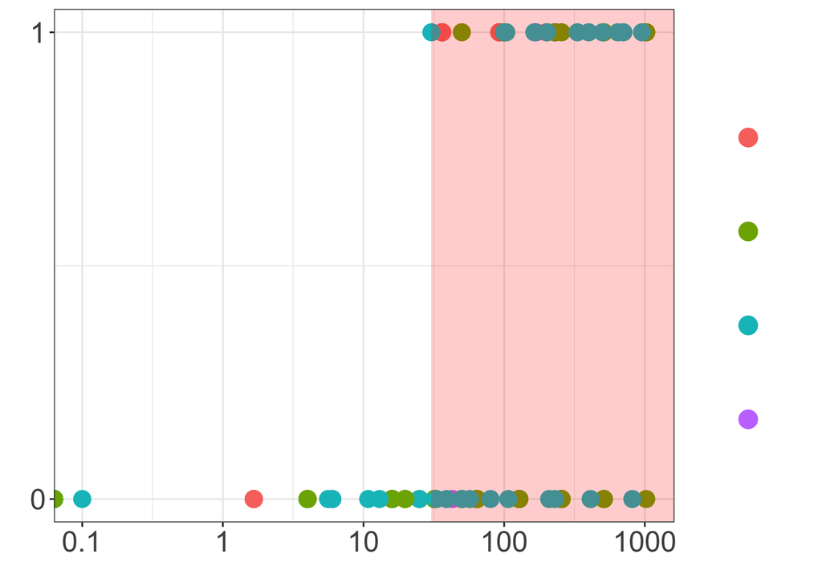

# Logistic Regression Model Fitting

[output not shown]

```
## Data: fertSS2
## Models:
## mod6: Binary_reduced_fertilization ~ Sed_level_stand_mg * Sed_exposure_days +
## mod6:     (1 | Gsp)
## mod9: Binary_reduced_fertilization ~ Sed_level_stand_mg * Sed_exposure_days +
## mod9:     (1 | Ref)
## mod12: Binary_reduced_fertilization ~ Sed_level_stand_mg * Sed_exposure_days +
## mod12:     (1 | Gsp) + (1 | Ref)
## mod15: Binary_reduced_fertilization ~ Sed_level_stand_mg * Sed_exposure_days +
## mod15:     (1 | Ref_name/Ref)
## mod18: Binary_reduced_fertilization ~ Sed_level_stand_mg * Sed_exposure_days +
## mod18:     (1 | Gsp) + (1 | Ref_name)
## mod21: Binary_reduced_fertilization ~ Sed_level_stand_mg * Sed_exposure_days +
## mod21:     (1 | Gsp) + (1 | Ref_name/Ref)
##       npar    AIC    BIC  logLik deviance  Chisq Df Pr(>Chisq)
## mod6     5 119.00 132.50 -54.499  108.998
## mod9     5 109.56 123.06 -49.779   99.558 9.4398  0  < 2.2e-16 ***
## mod12    6 111.56 127.76 -49.779   99.558 0.0000  1   0.999135
## mod15    6 111.56 127.76 -49.779   99.558 0.0000  0  < 2.2e-16 ***
## mod18    6 119.83 136.03 -53.915  107.830 0.0000  0   1.000000
## mod21    7 113.56 132.46 -49.779   99.558 8.2724  1   0.004025 **
## ---
## Signif. codes:  0 '***' 0.001 '**' 0.01 '*' 0.05 '.' 0.1 ' ' 1
```

```
## Data: fertSS2
## Models:
## mod7: Binary_reduced_fertilization ~ Sed_level_stand_mg + (1 | Ref)
## mod8: Binary_reduced_fertilization ~ Sed_level_stand_mg + Sed_exposure_days +
## mod8:     (1 | Ref)
## mod9: Binary_reduced_fertilization ~ Sed_level_stand_mg * Sed_exposure_days +
## mod9:     (1 | Ref)
##      npar    AIC    BIC  logLik deviance  Chisq Df Pr(>Chisq)
## mod7    3 106.99 115.09 -50.495  100.990
## mod8    4 108.63 119.43 -50.313  100.627 0.3632  1     0.5467
## mod9    5 109.56 123.06 -49.779   99.558 1.0690  1     0.3012
```

```
## Data: fertSS2
## Models:
## mod4: Binary_reduced_fertilization ~ Sed_level_stand_mg + (1 | Gsp)
## mod7: Binary_reduced_fertilization ~ Sed_level_stand_mg + (1 | Ref)
## mod10: Binary_reduced_fertilization ~ Sed_level_stand_mg + (1 | Gsp) +
## mod10:     (1 | Ref)
## mod13: Binary_reduced_fertilization ~ Sed_level_stand_mg + (1 | Ref_name/Ref)
## mod16: Binary_reduced_fertilization ~ Sed_level_stand_mg + (1 | Gsp) +
## mod16:     (1 | Ref_name)
##       npar    AIC    BIC  logLik deviance  Chisq Df Pr(>Chisq)
## mod4     3 115.63 123.73 -54.816   109.63
## mod7     3 106.99 115.09 -50.495   100.99 8.6426  0     <2e-16 ***
## mod10    4 108.99 119.79 -50.495   100.99 0.0000  1     0.9993
## mod13    4 108.99 119.79 -50.495   100.99 0.0000  0     <2e-16 ***
## mod16    4 117.02 127.82 -54.509   109.02 0.0000  0     1.0000
## ---
## Signif. codes:  0 '***' 0.001 '**' 0.01 '*' 0.05 '.' 0.1 ' ' 1
```

```
## Generalized linear mixed model fit by maximum likelihood (Laplace
##   Approximation) [glmerMod]
##  Family: binomial  ( logit )
## Formula: Binary_reduced_fertilization ~ Sed_level_stand_mg + (1 | Ref)
##    Data: fertSS2
##
##      AIC      BIC   logLik deviance df.resid
##    107.0    115.1    -50.5    101.0      107
##
## Scaled residuals:
##     Min      1Q  Median      3Q     Max
## -4.2172 -0.4304 -0.2074  0.3716  2.7457
##
## Random effects:
##  Groups Name        Variance Std.Dev.
##  Ref    (Intercept) 1.529    1.237
## Number of obs: 110, groups:  Ref, 10
##
## Fixed effects:
##                     Estimate Std. Error z value Pr(>|z|)
## (Intercept)        -1.471021   0.533091  -2.759 0.005790 **
## Sed_level_stand_mg  0.005863   0.001534   3.821 0.000133 ***
## ---
## Signif. codes:  0 '***' 0.001 '**' 0.01 '*' 0.05 '.' 0.1 ' ' 1
## convergence code: 0
## Model is nearly unidentifiable: very large eigenvalue
##  - Rescale variables?
```

```
##    n
## 1 86
```

```
## boundary (singular) fit: see ?isSingular
```

```
## Data: fertSS3
## Models:
## mod7_log: Binary_reduced_fertilization ~ log10_mg_L + (1 | Ref)
## mod7_log2: Binary_reduced_fertilization ~ log10_mg_L + (log10_mg_L | Ref)
##           npar    AIC    BIC  logLik deviance  Chisq Df Pr(>Chisq)
## mod7_log     3 73.352 80.715 -33.676   67.352
## mod7_log2    5 77.275 89.547 -33.637   67.275 0.0769  2     0.9623
```

```
## Generalized linear mixed model fit by maximum likelihood (Laplace
##   Approximation) [glmerMod]
##  Family: binomial  ( logit )
## Formula: Binary_reduced_fertilization ~ log10_mg_L + (1 | Ref)
##    Data: fertSS3
##
##      AIC      BIC   logLik deviance df.resid
##     73.4     80.7    -33.7     67.4       83
##
## Scaled residuals:
##     Min      1Q  Median      3Q     Max
## -3.4376 -0.2575 -0.0626  0.3318  2.1261
##
## Random effects:
##  Groups Name        Variance Std.Dev.
##  Ref    (Intercept) 6.288    2.508
## Number of obs: 86, groups:  Ref, 10
##
## Fixed effects:
##             Estimate Std. Error z value Pr(>|z|)
## (Intercept)   -7.310      2.310  -3.164 0.001555 **
## log10_mg_L     4.002      1.111   3.604 0.000314 ***
## ---
## Signif. codes:  0 '***' 0.001 '**' 0.01 '*' 0.05 '.' 0.1 ' ' 1
```

# Model Diagnostics, Random Effects, and Effect Estimates

```
## [1] 0.8837209
```

```
##
## p    0  1
##   0 49  5
##   1  5 27
```

```
## Area under the curve: 0.9534
```

```
##                   R2m       R2c
## theoretical 0.4034229 0.7950786
## delta       0.3856490 0.7600493
```

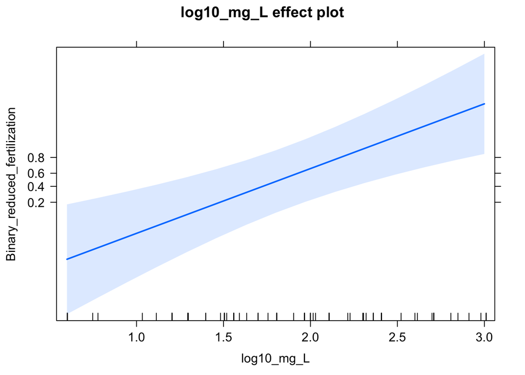

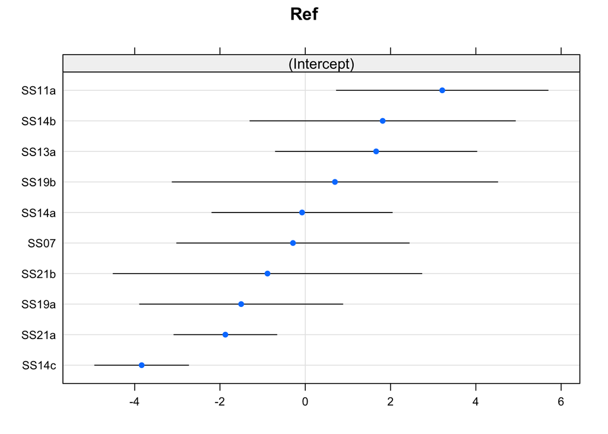

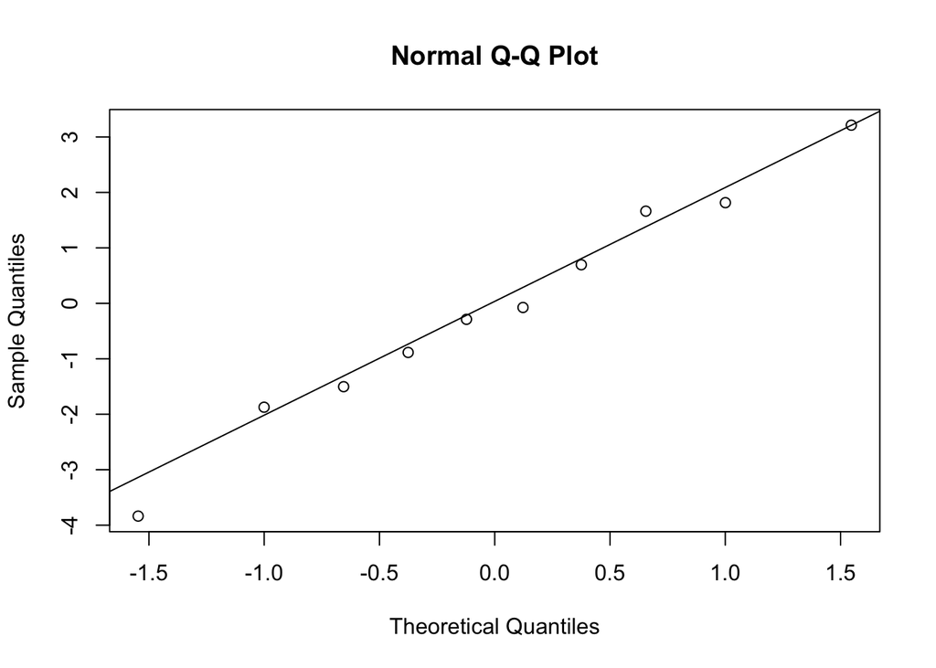

```
##  Groups Name        Std.Dev.
##  Ref    (Intercept) 2.5075
```

```
## [1] 12.27469
```

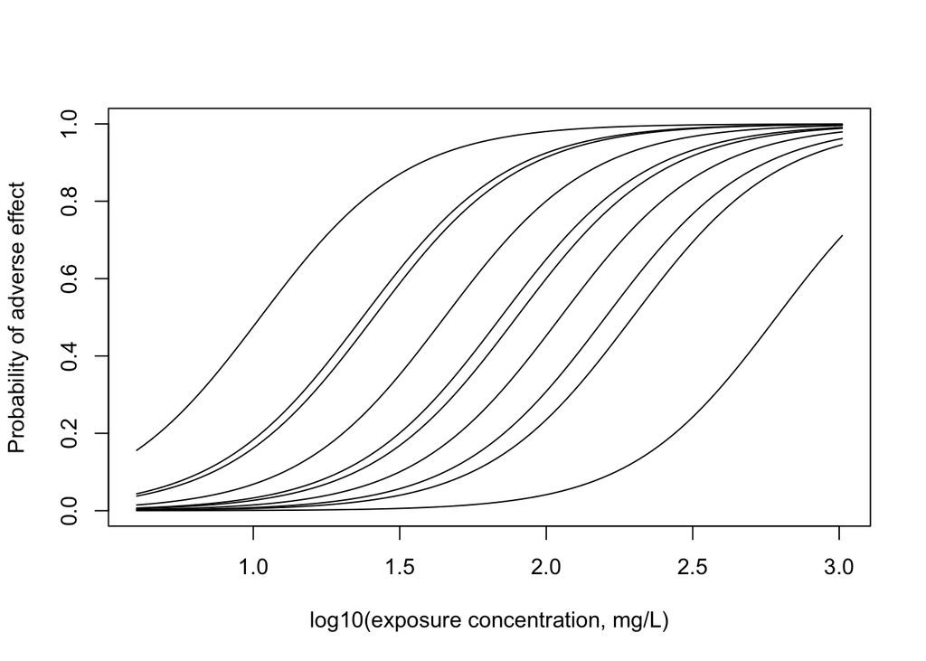

```
##                      Est           LL           UL
## (Intercept) 6.686841e-04 7.221468e-06   0.06191795
## log10_mg_L  5.471313e+01 6.205822e+00 482.37388230
```

For every 10-fold increase in sediment exposure, the odds of reduced fertilization success increase by 54.7 times (95% CI 6.2,482.4, GLMM p=0.0003), after accounting for the (random) effect of study. The fixed effect of sediment level explains 40.3% of variation of the total variation. If the random intercepts for studies are also included, then 79.5% of variation is explained.

# Prediction figure

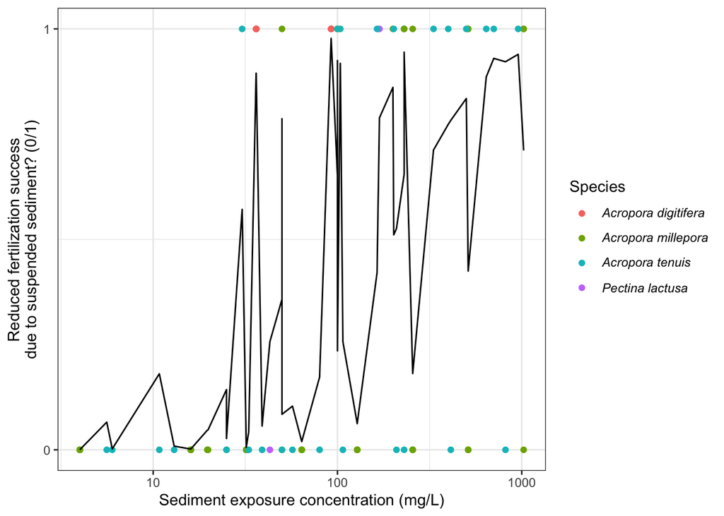

```r
#Overlaying glmm results on figure, but prediction line is jagged...
pred_mod7_log <- predict(mod7_log, newdata=fertSS3, type="response")
fertSS4 <- cbind(fertSS3, pred_mod7_log)

fertSS_plot3 <- ggplot(data = fertSS4) +
    geom_point(mapping = aes(
      x = Sed_level_stand_mg,
      y = Binary_reduced_fertilization,
      color = Gsp)) +
    labs(x = "Sediment exposure concentration (mg/L)",
         y = "Reduced fertilization success\ndue to suspended sediment? (0/1)",
         color = "Species") +
    scale_x_log10(breaks=c(0.01,0.1,1,10,100,1000),
                  label=c("0.01","0.1","1","10","100","1000")) +
    scale_y_continuous(breaks=c(0,1)) +
    geom_line(aes(x = Sed_level_stand_mg, y = pred_mod7_log), inherit.aes=FALSE) +
    theme_bw() +
    scale_color_discrete(labels = c(expression(italic("Acropora digitifera")),expression(italic("Acropora millepora")),expression(italic("Acropora tenuis")),expression(italic("Pectina lactusa")))) + theme(legend.text.align = 0)

fertSS_plot3
```

That plot is confusing to interpret. Let’s see if I can plot the average marginal probability, i.e., the average change in probability of the outcome across the range of the predictor of interest. This is described in some detail at the following, useful website: https://stats.idre.ucla.edu/r/dae/mixed-effects-logistic-regression/

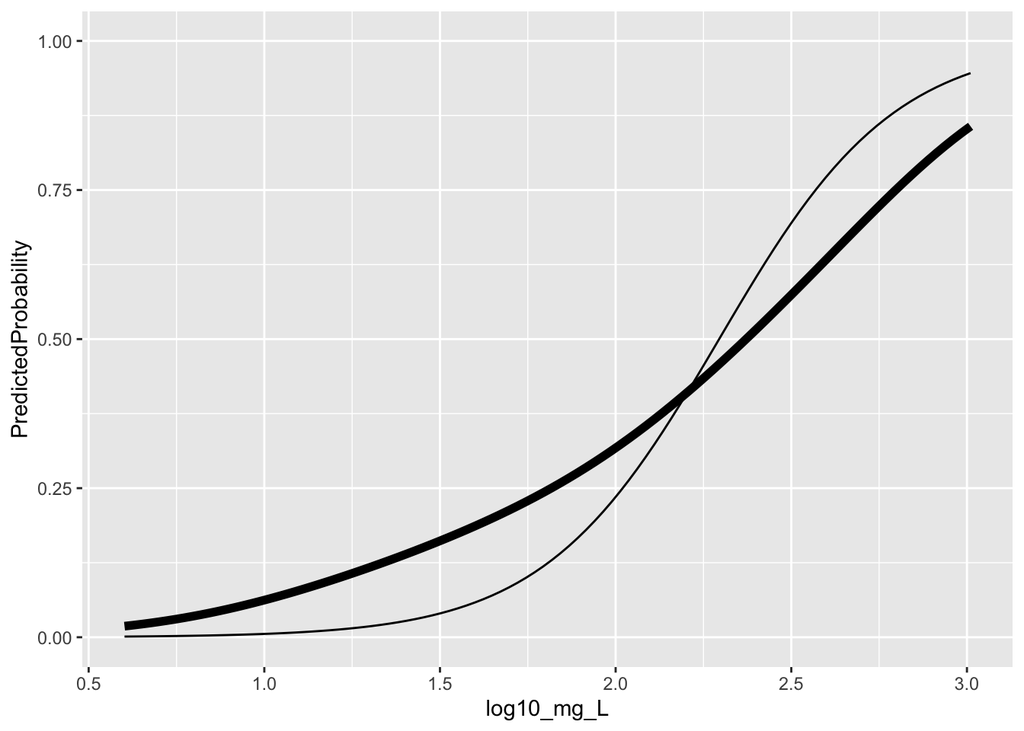

```r
#summary(fertSS3$log10_mg_L)
#   Min. 1st Qu.  Median    Mean 3rd Qu.    Max.
# 0.6021  1.5051  1.9657  1.8956  2.3617  3.0103

jvalues <- with(fertSS3, seq(from = min(log10_mg_L), to = max(log10_mg_L), length.out = 100))

# calculate predicted probabilities and store in a list
pp <- lapply(jvalues, function(j) {
    fertSS3$log10_mg_L <- j
    predict(mod7_log, newdata = fertSS3, type = "response")
})

# average marginal predicted probability across a few different sediment levels
#sapply(pp[c(1, 20, 40, 60, 80, 100)], mean)
## [1] 0.01857219 0.07270104 0.17399541 0.33310503 0.58820472 0.85682467
# get the means with lower and upper quartiles
plotdat <- t(sapply(pp, function(x) {
    c(M = mean(x), med = median(x), quantile(x, c(0.25, 0.75)))
}))

# add in log10_mg_L values and convert to data frame
plotdat <- as.data.frame(cbind(plotdat, jvalues))
plotdat <- plotdat %>% mutate(Sed_level_linear=10^jvalues)

# better names and show the first few rows
colnames(plotdat) <- c("PredictedProbability", "MedianProbability",
                       "LowerQuantile", "UpperQuantile", "log10_mg_L", "mg_L")
#head(plotdat)

# plot average marginal predicted probabilities
ggplot(plotdat, aes(x = log10_mg_L)) +
  geom_line(aes(y = PredictedProbability), size = 2) +
  geom_line(aes(y = MedianProbability), size = 0.5) +
  ylim(c(0, 1))
```

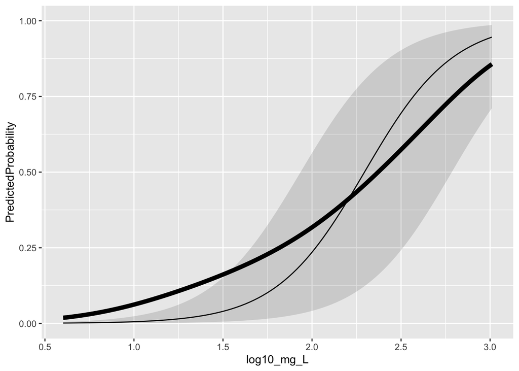

```r
ggplot(plotdat, aes(x = log10_mg_L)) +
  geom_ribbon(aes(ymin = LowerQuantile, ymax = UpperQuantile), alpha = 0.15) +
  geom_line(aes(y = PredictedProbability), size = 2) +
  geom_line(aes(y = MedianProbability), size = 0.5) +
  ylim(c(0, 1))
```

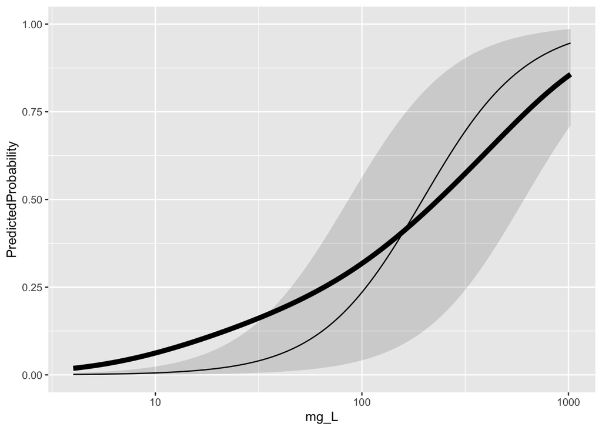

```r
ggplot(plotdat, aes(x = mg_L, y = PredictedProbability)) +
  geom_ribbon(aes(ymin = LowerQuantile, ymax = UpperQuantile), alpha = 0.15) +
  geom_line(aes(y = PredictedProbability), size = 2) +
  geom_line(aes(y = MedianProbability), size = 0.5) +
  ylim(c(0, 1)) +
  scale_x_log10()
```

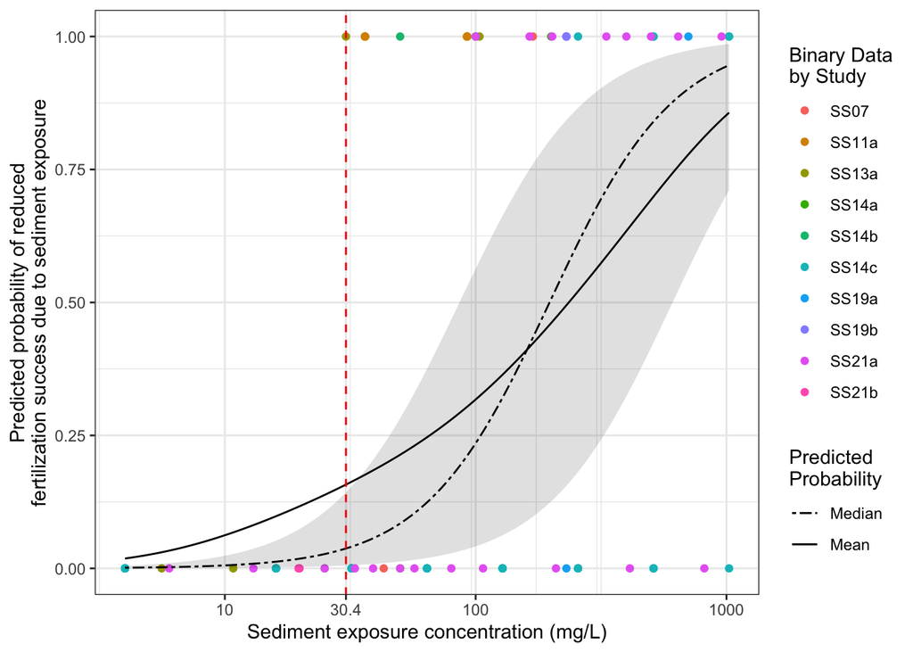

```r
#Overlaying average marginal predicted probabilities on figure
fertSS_plot3 <- ggplot() +
    geom_point(data = fertSS3, mapping = aes(
      x = Sed_level_stand_mg,
      y = Binary_reduced_fertilization,
      color = Ref)) +
    labs(x = "Sediment exposure concentration (mg/L)",
         y = "Predicted probability of reduced\nfertilization success due to sediment exposure",
         color = "Binary Data\nby Study",
         linetype = "Predicted\nProbability") +
    scale_x_log10(breaks=c(0.01,0.1,1,10,100,1000,loael),
                  label=c("0.01","0.1","1","10","100","1000",round(loael,digits=1))) +
    geom_ribbon(data = plotdat, aes(x = mg_L, y = PredictedProbability,
                                    ymin = LowerQuantile, ymax = UpperQuantile),
                alpha = 0.15) +
    geom_line(data = plotdat, aes(x = mg_L, y = PredictedProbability, linetype = "twodash")) +
    geom_line(data = plotdat, aes(x = mg_L, y = MedianProbability, linetype = "solid")) +
    geom_vline(xintercept=loael, linetype="dashed", color = "red") +
    theme_bw() +
    scale_linetype_manual(values=c("twodash", "solid"), labels = c("Median","Mean"))

#And now by Ref instead of species
fertSS_plot5 <- ggplot() +
    geom_point(data = fertSS3, mapping = aes(
      x = Sed_level_stand_mg,
      y = Binary_reduced_fertilization,
      color = Ref,
      shape = Gsp)) +
    labs(x = "Sediment exposure concentration (mg/L)",
         y = "Predicted probability of reduced\nfertilization success due to sediment exposure",
         color = "Study",
         shape = "Species") +
    scale_x_log10(breaks=c(0.01,0.1,1,10,100,1000),
                  label=c("0.01","0.1","1","10","100","1000")) +
    geom_ribbon(data = plotdat, aes(x = mg_L, y = PredictedProbability,
                                    ymin = LowerQuantile, ymax = UpperQuantile),
                alpha = 0.15) +
    geom_line(data = plotdat, aes(x = mg_L, y = PredictedProbability, linetype = "twodash")) +
    geom_line(data = plotdat, aes(x = mg_L, y = MedianProbability, linetype = "solid")) +
    theme_bw() +
    scale_shape_discrete(labels = c(expression(italic("Acropora digitifera")),expression(italic("Acropora millepora")),expression(italic("Acropora tenuis")),expression(italic("Pectina lactusa")))) + theme(legend.text.align = 0) +
    guides(linetype = FALSE, color = guide_legend(order=1), shape = guide_legend(order=2))

fertSS_plot3
```

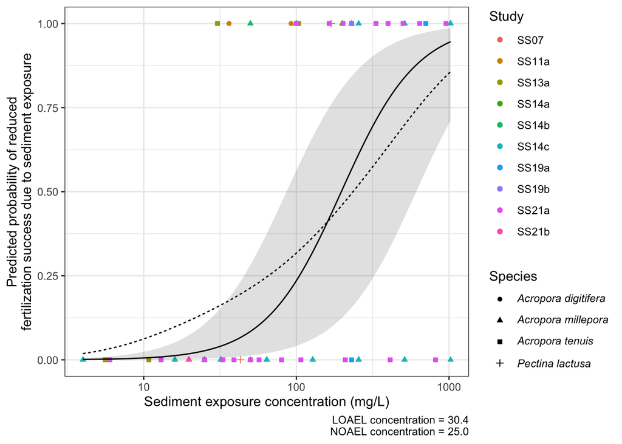

```r
fertSS_plot5 + labs(caption = "LOAEL concentration = 30.4\nNOAEL concentration = 25.0")
```

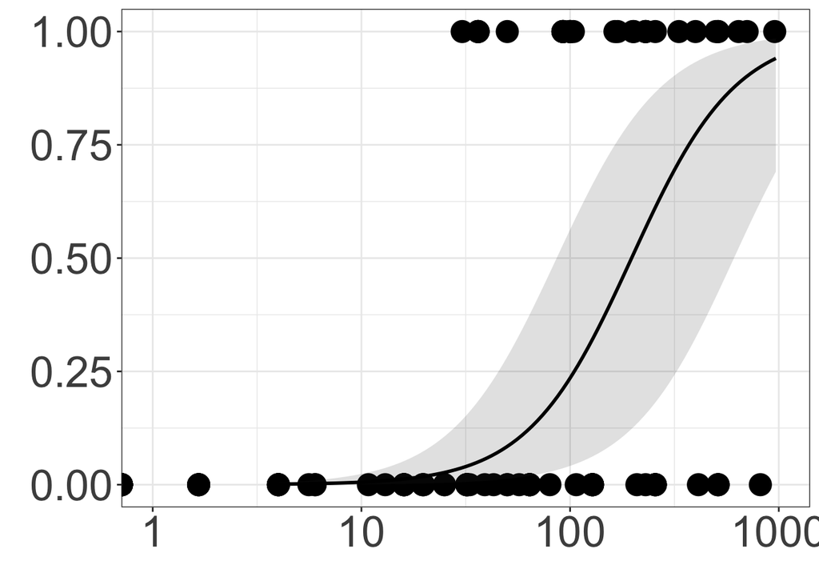

```r
#Plot for Fig. 2B
fertSS_plot4 + scale_y_continuous(breaks=c(0,0.25,0.5,0.75,1)) +
  geom_ribbon(data = plotdat,
              aes(x = mg_L, y = PredictedProbability,
                  ymin = LowerQuantile, ymax = UpperQuantile),
              alpha = 0.15) +
  geom_line(data = plotdat, aes(x = mg_L, y = MedianProbability, linetype = "solid", size = 2)) +
  theme(legend.position = "none")
```